# An Exploration of the Open Powerlifting dataset

*Andrew Lau*  
There's a great powerlifting data set that collates hundreds of thousands of powerlifting competition results. I thought I'd do a bit of exploration and fit a quick and dirty XGBoost model to see if I can gather some insight on the impact on the total lifted in competition of:

- age, particularly when people tend to "peak" in their lifting careers
- bodyweight
- gender
- equipment

I'm curious about the impacts of the above features on the typical powerlifter. Of course, one of the issues with this dataset is the self-selection bias of lifters (e.g. lifters tend to compete when they feel strong/uninjured). Particularly when looking at the impact of age, older lifters may just choose not to lift after years of accumulated injuries and declining performance and may not appear in the dataset.

The problem here is rather straightforward (there is a lot of clean data (>2m rows), there aren't that many features available) and I'm just curious about the "pure effect" of the features on the target. To make the problem even simpler, the general impact of features like age, gender, drug testing and bodyweight are known within the powerlifting community (e.g. we know that in general males lift more and heavier lifters lift more).

Thus, a quick and dirty model will suffice (e.g. I will just use the tried and tested XGBoost with no feature engineering, basic pre-processing, minimal hyperparameter tuning).

Data sourced from: https://www.openpowerlifting.org/

```python
import pandas as pd
import matplotlib.pyplot as plt
from sklearn.model_selection import train_test_split
from xgboost import XGBRegressor
import seaborn as sns
from sklearn.impute import SimpleImputer
import numpy as np
from sklearn.metrics import mean_squared_error
import shap
import statsmodels.api as sm
from sklearn.model_selection import RandomizedSearchCV
import pickle

pd.set_option('display.max_columns', None)

N_JOBS = 6
```

```python
# import the data
data = pd.read_csv("openpowerlifting-2021-01-20.csv",
                  low_memory=False)
```

```python
data.shape
```

```
(2301966, 41)
```

```python
display(data)
```

|  | Name | Sex | Event | Equipment | Age | AgeClass | BirthYearClass | Division | BodyweightKg | WeightClassKg | Squat1Kg | Squat2Kg | Squat3Kg | Squat4Kg | Best3SquatKg | Bench1Kg | Bench2Kg | Bench3Kg | Bench4Kg | Best3BenchKg | Deadlift1Kg | Deadlift2Kg | Deadlift3Kg | Deadlift4Kg | Best3DeadliftKg | TotalKg | Place | Dots | Wilks | … |
| --- | --- | --- | --- | --- | --- | --- | --- | --- | --- | --- | --- | --- | --- | --- | --- | --- | --- | --- | --- | --- | --- | --- | --- | --- | --- | --- | --- | --- | --- | --- |
| 0 | Dominik Gabriel | M | B | Raw | 17.0 | 16-17 | 14-18 | T 16-17 | 102.5 | 110 | NaN | NaN | NaN | NaN | NaN | 120.0 | 130.0 | -140.0 | NaN | 130.0 | NaN | NaN | NaN | NaN | NaN | 130.0 | 1 | 79.18 | 78.36 | … |
| 1 | Marek Herák | M | B | Multi-ply | 19.0 | 18-19 | 19-23 | T 18-19 | 59.8 | 60 | NaN | NaN | NaN | NaN | NaN | 165.0 | -175.0 | 175.0 | -180.0 | 175.0 | NaN | NaN | NaN | NaN | NaN | 175.0 | 1 | 148.11 | 149.71 | … |
| 2 | Miroslav Adamove | M | B | Multi-ply | 18.0 | 18-19 | 14-18 | T 18-19 | 87.7 | 90 | NaN | NaN | NaN | NaN | NaN | 250.0 | -270.0 | -270.0 | NaN | 250.0 | NaN | NaN | NaN | NaN | NaN | 250.0 | 1 | 163.81 | 161.77 | … |
| 3 | Kamil Lipiňski | M | B | Multi-ply | 19.0 | 18-19 | 19-23 | T 18-19 | 89.5 | 90 | NaN | NaN | NaN | NaN | NaN | -170.0 | -180.0 | -180.0 | NaN | NaN | NaN | NaN | NaN | NaN | NaN | NaN | DQ | NaN | NaN | … |
| 4 | Gabriel Kováč | M | B | Multi-ply | 20.0 | 20-23 | 19-23 | Juniors | 81.6 | 82.5 | NaN | NaN | NaN | NaN | NaN | 260.0 | 280.0 | -290.0 | NaN | 280.0 | NaN | NaN | NaN | NaN | NaN | 280.0 | 1 | 190.86 | 188.82 | … |
| ... | ... | ... | ... | ... | ... | ... | ... | ... | ... | ... | ... | ... | ... | ... | ... | ... | ... | ... | ... | ... | ... | ... | ... | ... | ... | ... | ... | ... | ... | … |
| 2301961 | Fady Meilad | M | SBD | Raw | 34.5 | 24-34 | 24-39 | Open | 94.5 | 105 | 200.0 | 210.0 | -225.0 | NaN | 210.0 | 150.0 | 160.0 | -165.0 | NaN | 160.0 | 230.0 | 250.0 | -255.0 | NaN | 250.0 | 620.0 | 2 | 391.49 | 386.58 | … |
| 2301962 | Mohamed Omar | M | SBD | Raw | 30.5 | 24-34 | 24-39 | Open | 110.3 | 120 | 150.0 | NaN | NaN | NaN | 150.0 | -100.0 | 100.0 | 115.0 | NaN | 115.0 | -230.0 | 240.0 | -265.0 | NaN | 240.0 | 505.0 | 2 | 298.79 | 296.94 | … |
| 2301963 | Boudjemaa Nait Ladjemil | M | SBD | Raw | 33.5 | 24-34 | 24-39 | Open | 116.4 | 120 | 270.0 | 290.0 | -300.0 | NaN | 290.0 | 170.0 | 177.5 | 182.5 | NaN | 182.5 | 280.0 | 300.0 | 312.5 | NaN | 312.5 | 785.0 | 1 | 455.52 | 454.68 | … |
| 2301964 | Mohamed Eldeken | M | SBD | Raw | 38.5 | 35-39 | 24-39 | Open | 128.3 | 120+ | 150.0 | NaN | NaN | NaN | 150.0 | 100.0 | NaN | NaN | NaN | 100.0 | 150.0 | NaN | NaN | NaN | 150.0 | 400.0 | 2 | 224.87 | 226.78 | … |
| 2301965 | Mohamed Bouafia | M | SBD | Raw | 38.0 | 35-39 | 24-39 | Open | 130.5 | 120+ | 350.0 | 375.0 | 390.0 | NaN | 390.0 | 210.0 | 220.0 | 222.5 | NaN | 222.5 | 335.0 | 355.0 | -367.5 | NaN | 355.0 | 967.5 | 1 | 541.12 | 546.84 | … |

2301966 rows × 41 columns

# Exploratory data analysis

Let's have a play around with the data and see what it looks like.

## Target distribution

Let's take a cheeky look at a random subset of the data.

```python
data_EDA = data.sample(n=100_000, random_state=1)
```

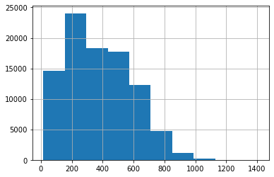

```python
data_EDA.TotalKg.hist()
```

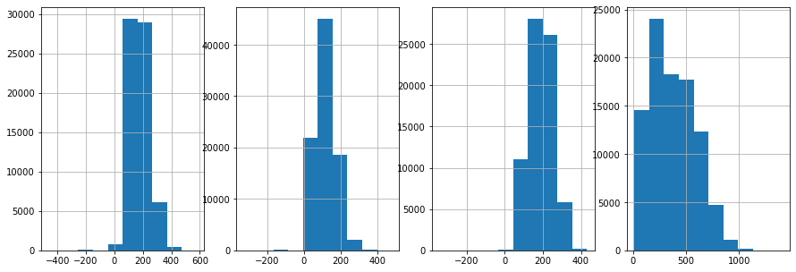

```python
# Let's check out are target, the comp total
fig, (ax1, ax2, ax3, ax4) = plt.subplots(1, 4, figsize=(15,5))

#, legend=True after updating pandas
data_EDA.Best3SquatKg.hist(ax=ax1)
data_EDA.Best3BenchKg.hist(ax=ax2)
data_EDA.Best3DeadliftKg.hist(ax=ax3)
data_EDA.TotalKg.hist(ax=ax4)
```

Distribution of the target as well as the best bench, squat and deadlift is consistent with my anectoal experience and seems reasonable.

```python
data.describe()
# there seems to be negatives in the weights lifted. I'm guessing the negatives are bad lifts
```

|  | Age | BodyweightKg | Squat1Kg | Squat2Kg | Squat3Kg | Squat4Kg | Best3SquatKg | Bench1Kg | Bench2Kg | Bench3Kg | Bench4Kg | Best3BenchKg | Deadlift1Kg | Deadlift2Kg | Deadlift3Kg | Deadlift4Kg | Best3DeadliftKg | TotalKg | Dots | Wilks | Glossbrenner | Goodlift |
| --- | --- | --- | --- | --- | --- | --- | --- | --- | --- | --- | --- | --- | --- | --- | --- | --- | --- | --- | --- | --- | --- | --- |
| count | 1.405630e+06 | 2.272788e+06 | 548366.000000 | 541887.000000 | 525775.000000 | 5965.000000 | 1.512067e+06 | 917694.000000 | 906210.000000 | 876436.000000 | 16381.000000 | 2.019193e+06 | 629286.000000 | 616535.000000 | 587107.000000 | 15711.000000 | 1.638153e+06 | 2.137665e+06 | 2.118599e+06 | 2.118599e+06 | 2.118599e+06 | 1.929263e+06 |
| mean | 3.100391e+01 | 8.405366e+01 | 112.103324 | 92.430403 | 32.275855 | 72.392890 | 1.749615e+02 | 83.474699 | 55.112395 | -18.091854 | 23.887011 | 1.193173e+02 | 159.314554 | 129.661601 | 16.392483 | 77.594206 | 1.893182e+02 | 3.755357e+02 | 2.731590e+02 | 2.721775e+02 | 2.566639e+02 | 6.390920e+01 |
| std | 1.318477e+01 | 2.273521e+01 | 144.052702 | 169.183631 | 196.035332 | 188.238942 | 6.995331e+01 | 104.345559 | 129.211113 | 143.203392 | 164.077946 | 5.483921e+01 | 109.758061 | 160.004725 | 212.291169 | 188.829659 | 6.252989e+01 | 2.069084e+02 | 1.302450e+02 | 1.297588e+02 | 1.234186e+02 | 1.619867e+01 |
| min | 0.000000e+00 | 1.510000e+01 | -555.000000 | -580.000000 | -600.500000 | -550.000000 | -5.080200e+02 | -502.500000 | -575.000000 | -575.000000 | -500.000000 | -5.225000e+02 | -461.000000 | -470.000000 | -587.500000 | -461.000000 | -4.100000e+02 | 1.000000e+00 | 6.800000e-01 | 6.700000e-01 | 6.400000e-01 | 5.000000e-01 |
| 25% | 2.100000e+01 | 6.705000e+01 | 87.500000 | 70.000000 | -160.000000 | -100.000000 | 1.225000e+02 | 55.000000 | -52.500000 | -140.000000 | -125.000000 | 7.711000e+01 | 125.000000 | 115.000000 | -205.000000 | -100.000000 | 1.400000e+02 | 2.000000e+02 | 1.407300e+02 | 1.402100e+02 | 1.327900e+02 | 5.219000e+01 |
| 50% | 2.750000e+01 | 8.196000e+01 | 145.000000 | 142.900000 | 110.000000 | 131.000000 | 1.700000e+02 | 105.000000 | 95.000000 | -60.000000 | 75.000000 | 1.150000e+02 | 180.000000 | 177.500000 | 117.500000 | 142.500000 | 1.900000e+02 | 3.500000e+02 | 2.938400e+02 | 2.929600e+02 | 2.735200e+02 | 6.362000e+01 |
| 75% | 3.900000e+01 | 9.890000e+01 | 200.000000 | 202.500000 | 190.000000 | 200.000000 | 2.200000e+02 | 145.000000 | 145.000000 | 120.000000 | 155.000000 | 1.542200e+02 | 225.000000 | 230.000000 | 205.000000 | 206.380000 | 2.350000e+02 | 5.307000e+02 | 3.715400e+02 | 3.700700e+02 | 3.504900e+02 | 7.517000e+01 |
| max | 9.800000e+01 | 2.602000e+02 | 555.000000 | 577.500000 | 560.000000 | 592.390000 | 5.810500e+02 | 467.500000 | 487.500000 | 478.540000 | 487.610000 | 5.034900e+02 | 450.000000 | 460.400000 | 457.500000 | 440.500000 | 4.604000e+02 | 1.407500e+03 | 7.952200e+02 | 7.933300e+02 | 7.569000e+02 | 1.464900e+02 |

## One-way analysis

Let's plot some one-way charts to give us a feel of certain features on the target. Of course, these won't be "pure effects" as such, as they will be confounding by correlated variables (mix effects - for example a one-way chart of total lifted vs. weight may overestimate the pure effect of weight as higher weights are correlated with being male).

```python
def one_way(x_var, y_var, data, axis):
    ax = sns.regplot(x=x_var, y=y_var, data=data, lowess=True, scatter_kws={"alpha":0.1},
                     line_kws={"color": "red"}, ax=axis)
```

Let's have a look at the impact of some features on amount lifted

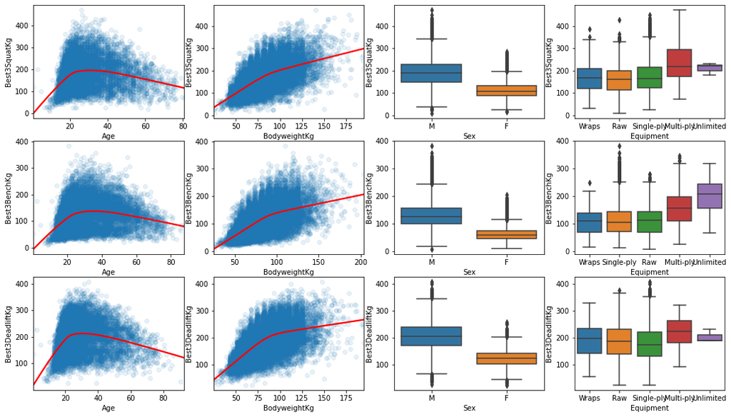

```python
data_subset = data_EDA.loc[data_EDA.Tested == "Yes"].sample(n=25_000, random_state=1)

fig, ((ax1, ax2, ax3, ax4), (ax5, ax6, ax7, ax8), (ax9, ax10, ax11, ax12)) = plt.subplots(3, 4, figsize=(17.5,10))

one_way("Age", "Best3SquatKg", data=data_subset[data_subset.Best3SquatKg > 0],
       axis=ax1)
one_way("BodyweightKg", "Best3SquatKg", data=data_subset[data_subset.Best3SquatKg > 0],
       axis=ax2)
sns.boxplot(x="Sex", y="Best3SquatKg", data=data_subset[data_subset.Best3SquatKg > 0], ax=ax3)
sns.boxplot(x="Equipment", y="Best3SquatKg", data=data_subset[data_subset.Best3SquatKg > 0], ax=ax4)


one_way("Age", "Best3BenchKg", data=data_subset[data_subset.Best3BenchKg > 0],
       axis=ax5)
one_way("BodyweightKg", "Best3BenchKg", data=data_subset[data_subset.Best3BenchKg > 0],
       axis=ax6)
sns.boxplot(x="Sex", y="Best3BenchKg", data=data_subset[data_subset.Best3BenchKg > 0], ax=ax7)
sns.boxplot(x="Equipment", y="Best3BenchKg", data=data_subset[data_subset.Best3BenchKg > 0], ax=ax8)

one_way("Age", "Best3DeadliftKg", data=data_subset[data_subset.Best3DeadliftKg > 0],
       axis=ax9)
one_way("BodyweightKg", "Best3DeadliftKg", data=data_subset[data_subset.Best3DeadliftKg > 0],
       axis=ax10)
sns.boxplot(x="Sex", y="Best3DeadliftKg", data=data_subset[data_subset.Best3DeadliftKg > 0], ax=ax11)
sns.boxplot(x="Equipment", y="Best3DeadliftKg", data=data_subset[data_subset.Best3DeadliftKg > 0], ax=ax12)

plt.show()
```

The average lifter appears to peak around the age of 30, before declining over time. The deterioration as the average lifter ages is better than what I was expecting. As expected bodyweight has a significant impact on weight lifted. Again, I note that these are averages and are impacted by conflating/correlated variables. As expected, males tend to lift more and equipped lifters also tend to lift more.

# Pre-processing

## Feature selection and missing data imputation

I'm just fitting a quick and dirty model here, so I'm removing duplicated/redudant features and not bothering with any feature engineering.

```python
features_list = ['Age',
#  'AgeClass',
#  'Bench1Kg',
#  'Bench2Kg',
#  'Bench3Kg',
#  'Bench4Kg',
#  'Best3BenchKg',
#  'Best3DeadliftKg',
#  'Best3SquatKg',
#  'BirthYearClass',
 'BodyweightKg',
 'Country',
#  'Date',
#  'Deadlift1Kg',
#  'Deadlift2Kg',
#  'Deadlift3Kg',
#  'Deadlift4Kg',
#  'Division',
#  'Dots',
 'Equipment',
 'Event',
#  'Federation',
#  'Glossbrenner',
#  'Goodlift',
#  'MeetCountry',
#  'MeetName',
#  'MeetState',
#  'MeetTown',
#  'Name',
 'ParentFederation',
#  'Place',
 'Sex',
#  'Squat1Kg',
#  'Squat2Kg',
#  'Squat3Kg',
#  'Squat4Kg',
#  'State',
#  'T',
 'Tested',
#  'TotalKg',
#  'WeightClassKg',
#  'Wilks'
                ]
```

```python
# feature selection
X = data[features_list]

# one hot encoding on full dataset to avoid categorical levels not in training but in valid/test
X = pd.get_dummies(X, drop_first=True)
X_col_names = X.columns

y = data["TotalKg"]

# removing rows where there isn't a total, the age and bodyeight are invalid
y_notna = ~y.isna()
X_valid_age = X.Age > 10
X_valid_weight = X.BodyweightKg > 20

mask = y_notna & X_valid_age & X_valid_weight

y = y[mask]
X = X[mask]

print("na in y_train:", y.isna().sum())
print("na in X_train:", np.sum(np.isnan(X)))
```

```
na in y_train: 0
na in X_train: Age                       0
BodyweightKg              0
Country_Afghanistan       0
Country_Algeria           0
Country_American Samoa    0
                         ..
ParentFederation_WRPF     0
ParentFederation_WUAP     0
ParentFederation_XPC      0
Sex_M                     0
Sex_Mx                    0
Length: 224, dtype: int64
```

```python
# train test split
# 20% test, 20% validation, 60% training
X_train, X_test, y_train, y_test = train_test_split(X, y, test_size=0.2, random_state=1)
X_train, X_valid, y_train, y_valid = train_test_split(X_train, y_train, test_size=0.25, random_state=1)
```

```python
data.shape
```

```
(2301966, 41)
```

```python
# imputing missing values. not needed for XGB, used for testing out other ML models that can't handle missing data
# imp = SimpleImputer(missing_values=np.nan, strategy='median')
# X_train = imp.fit_transform(X_train)
# X_valid = imp.fit_transform(X_valid)
# X_test = imp.fit_transform(X_test)
```

# Fitting a model - XGBoost

We now fit a model to see get a better understanding of the "pure effects" of the features. There is quite a bit of data and the problem is fairly straightforward, so we just default to the trusty XGBoost model. We conduct a light random gridsearch. Early stopping rounds and a validation data set were used to help find the optimal number of estimators at each fit.

```python
# fitted this earlier on Google Cloud Platform
# xgb_1 = XGBRegressor(objective="reg:squarederror", n_estimators=500, n_jobs=16)
# eval_set = [(X_valid, y_valid)]


# gbm_param_grid = {
#     'max_depth': [2, 6],
#     'learning_rate': [0.01, 0.1],
#     'gamma': [0, 0.5, 2],
#     'colsample_bytree':[0.8, 1]
# }

# fit_params={"early_stopping_rounds":25,
#             "eval_set" : [[X_valid, y_valid]]
#            }

# # Perform random search: grid_mse
# random_search = RandomizedSearchCV(xgb_1,
#                                    cv=4,
#                                    param_distributions=gbm_param_grid,
#                                    n_iter=5,
#                                    n_jobs=2,
#                                    verbose=False,
#                                    random_state=123,
#                                   )

# random_search.fit(X_train, y_train, **fit_params)
```

```python
# pickle.dump(random_search, open("random_search.pickle", 'wb'))
random_search = pickle.load(open("random_search.pickle", 'rb'))
```

```python
random_search.best_estimator_.get_params()
```

```
{'objective': 'reg:squarederror',
 'base_score': 0.5,
 'booster': 'gbtree',
 'colsample_bylevel': 1,
 'colsample_bynode': 1,
 'colsample_bytree': 1,
 'gamma': 0,
 'gpu_id': -1,
 'importance_type': 'gain',
 'interaction_constraints': '',
 'learning_rate': 0.1,
 'max_delta_step': 0,
 'max_depth': 6,
 'min_child_weight': 1,
 'missing': nan,
 'monotone_constraints': '()',
 'n_estimators': 500,
 'n_jobs': 16,
 'num_parallel_tree': 1,
 'random_state': 0,
 'reg_alpha': 0,
 'reg_lambda': 1,
 'scale_pos_weight': 1,
 'subsample': 1,
 'tree_method': 'exact',
 'validate_parameters': 1,
 'verbosity': None}
```

# Diagnostics

## MSE and MAPE

```python
best_iter = random_search.best_estimator_.best_iteration
y_train_pred = random_search.best_estimator_.predict(X_train, ntree_limit=best_iter)
y_valid_pred = random_search.best_estimator_.predict(X_valid, ntree_limit=best_iter)
y_test_pred = random_search.best_estimator_.predict(X_test, ntree_limit=best_iter)

print("MSE on training data:", mean_squared_error(y_train, y_train_pred))
print("MSE on validation data:", mean_squared_error(y_valid, y_valid_pred))
print("MSE on test data:", mean_squared_error(y_test, y_test_pred))

def mean_absolute_percentage_error(y_true, y_pred):
    return np.mean(abs(y_true / y_pred - 1))

print("MAPE on training data:", mean_absolute_percentage_error(y_train, y_train_pred))
print("MAPE on validation data:", mean_absolute_percentage_error(y_valid, y_valid_pred))
print("MAPE on test data:", mean_absolute_percentage_error(y_test, y_test_pred))
```

```
MSE on training data: 4349.150095184332
MSE on validation data: 4446.135423677414
MSE on test data: 4410.636658830921
MAPE on training data: 0.13601618227032103
MAPE on validation data: 0.13763610656733644
MAPE on test data: 0.13728857659985094
```

The mean squared error for the validation/test dataset aren't significantly worse than the the training data. No signs of overfitting here. MSE is a little hard to interpret, so we also look at MAPE (mean absolute percentage error) to get a feel of the average percentage prediction error. Around 13-14% on all splits of the data, seems like a reasonable model.

## One-ways by key factors

We compare the average fitted and actuals by key factors to see if there are any segments that do not fit well. The fit looks quite good. The fit deteriorates a bit for higher ages/weights, but they are low exposure segments.

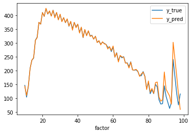

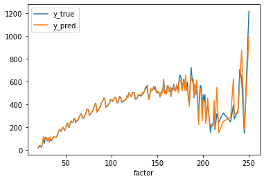

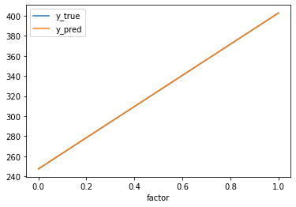

```python
pd.DataFrame({"factor":X_valid.loc[:, "Age"].round(), "y_true":y_valid, "y_pred":y_valid_pred}).groupby("factor").mean().plot()
pd.DataFrame({"factor":X_valid.loc[:, "BodyweightKg"].round(), "y_true":y_valid, "y_pred":y_valid_pred}).groupby("factor").mean().plot()
pd.DataFrame({"factor":X_valid.loc[:, "Sex_M"], "y_true":y_valid, "y_pred":y_valid_pred}).groupby("factor").mean().plot()
```

## Quantile plot

The next diagnostic we look at is the quantile plot. We compare predicted and actuals by quantiles.

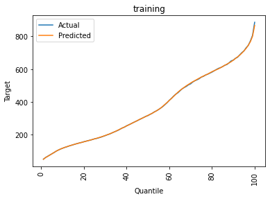

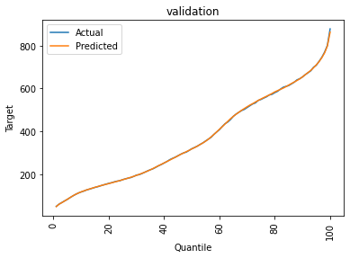

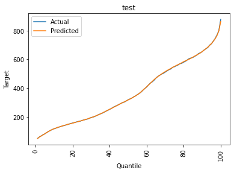

```python
def quantile_plot(y_true, y_pred, quantiles=10, scale=1.0, title=None, return_df=False):
    """
    description: plots a quantile plot based on sorting observations by y_pred
        and grouping them into quantiles.
    inputs:
        y_true - array like object of actuals
        y_pred - array like object of predicted values
        quantiles - number of quantiles/bins to separate the data
        scale - the predicted values can be scaled to focus on the ability of
            the model to rank the observations
        title - plot title
        return_df - False. Whether to return a pandas dataframe with the quantiles
    returns:
        DataFrame with y_true and y_pred grouped into quantiles sorted by y_pred
    """
    if scale == "auto":
        scale_used = sum(y_true) / sum(y_pred)
    else:
        scale_used = scale

    df = pd.DataFrame({'Actual':np.array(y_true).reshape(-1),
                                  'Predicted':np.array(y_pred).reshape(-1) * scale_used})
    df = df.groupby(pd.qcut(df.rank(method="first").loc[:, "Predicted"], quantiles)).mean()
    df.loc[:, "Quantile"] = (list(range(1, quantiles + 1)))
    df = df.set_index("Quantile")

    df.plot()
    plt.gca().set_ylabel("Target")
    plt.xticks(rotation = 90)

    if title:
        plt.title(title)
    else:
        plt.title("Predicted vs. Observed (" + str(quantiles) + " quantiles)")

    if return_df:
        return df

quantile_plot(y_train, y_train_pred, quantiles=100, scale=1.0, title="training")
quantile_plot(y_valid, y_valid_pred, quantiles=100, scale=1.0, title="validation")
quantile_plot(y_valid, y_valid_pred, quantiles=100, scale=1.0, title="test")
```

Quantile plot looks good - the predictions are close to the actuals in each quantile and there is decent separation between the high and low quantiles

## Lorenz curve

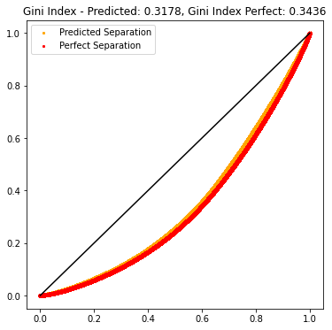

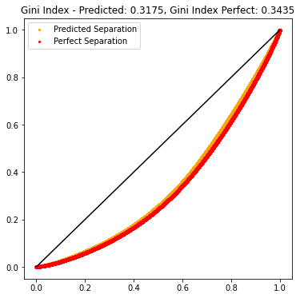

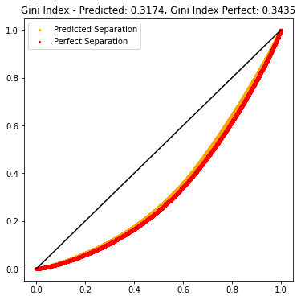

```python
def gini_score(y_true, y_pre, **kwargs):
    """
    description: model scoring metric. returns gini index.
    input: y_true, y_pre
    returns: gini score
    adapted from: https://zhiyzuo.github.io/Plot-Lorenz/
    """
    sorted_arr = np.array([x for _, x in sorted(zip(y_true, y_pre))])
    n = sorted_arr.size
    coef_ = 2. / n
    const_ = (n + 1.) / n
    weighted_sum = sum([(i + 1) * yi for i, yi in enumerate(sorted_arr)])

    return coef_ * weighted_sum / (sorted_arr.sum()) - const_
def lorenz_curve(y_true, y_pred):
    """
    description: plots the lorenz curve based on y_true and y_pred.
    input: y_true, y_pre
    adapted from: https://zhiyzuo.github.io/Plot-Lorenz/
    """
    X = np.array([x for _,x in sorted(zip(y_true, y_pred))])

    X_lorenz = X.cumsum() / X.sum()
    X_lorenz = np.insert(X_lorenz, 0, 0)
    X_lorenz[0], X_lorenz[-1]
    fig, ax = plt.subplots(figsize=[6,6])
    ## scatter plot of Lorenz curve
    ax.scatter(np.arange(X_lorenz.size)/(X_lorenz.size-1), X_lorenz,
               marker='x', color='orange', s=5, label="Predicted Separation")

    # repeat for perfect separation
    X = np.array([x for _,x in sorted(zip(y_true, y_true))])

    X_lorenz = X.cumsum() / X.sum()
    X_lorenz = np.insert(X_lorenz, 0, 0)
    X_lorenz[0], X_lorenz[-1]

    ## scatter plot of Lorenz curve
    ax.scatter(np.arange(X_lorenz.size)/(X_lorenz.size-1), X_lorenz,
               marker='x', color='red', s=5, label="Perfect Separation")

    ## line plot of equality\
    ax.plot([0,1], [0,1], color='k')
    ax.set_title("Gini Index - Predicted: %.4f, Gini Index Perfect: %.4f" % (gini_score(y_true, y_pred), gini_score(y_true, y_true)))
    ax.legend()

lorenz_curve(y_train, y_train_pred)
lorenz_curve(y_valid, y_valid_pred)
lorenz_curve(y_test, y_test_pred)
```

# Interpreting results

Now that we're happy with this model, let's draw some insight from it!

## Feature importance

```python
# compute SHAP values
explainer = shap.TreeExplainer(random_search.best_estimator_)
shap_values = explainer.shap_values(X_train)
```

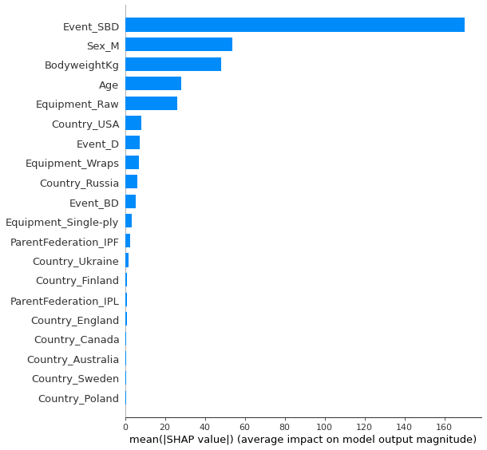

```python
shap.summary_plot(shap_values, features=X_train, feature_names=X_col_names, plot_type="bar")
```

The most important feature is the event, which makes sense, given the drastic differences in totals from a full powerlifting meet (squat, bench and deadlift) and a bench only meet. It's interesting how gender came up above bodyweight.

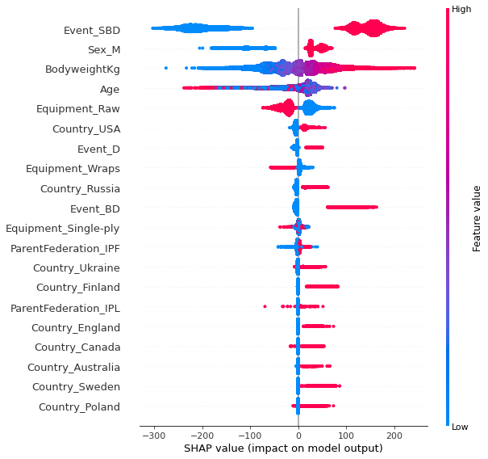

```python
shap.summary_plot(shap_values, features=X_train, feature_names=X_col_names)
```

The above chart shows the impact of the top features and the distributions of their SHAP values. When the colours mix, it implies an interaction with something else.

- A full powerlifting meeting has a positive impact on total
- Being male has a positive impact on total
- A heavier bodyweight has a positive impact on total
- Age is too heavily interacted with other features to discern a simple effect here
- Raw (minimal equipment) has a negative impact on total

## Partial dependencies

Let's look at some SHAP partial dependencies to analyse the pure effects of each feature

```
Passing parameters norm and vmin/vmax simultaneously is deprecated since 3.3 and will become an error two minor releases later. Please pass vmin/vmax directly to the norm when creating it.
```

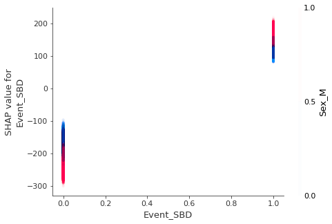

```
Passing parameters norm and vmin/vmax simultaneously is deprecated since 3.3 and will become an error two minor releases later. Please pass vmin/vmax directly to the norm when creating it.
```

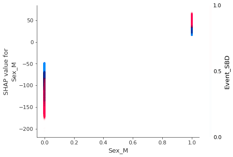

```
Passing parameters norm and vmin/vmax simultaneously is deprecated since 3.3 and will become an error two minor releases later. Please pass vmin/vmax directly to the norm when creating it.
```

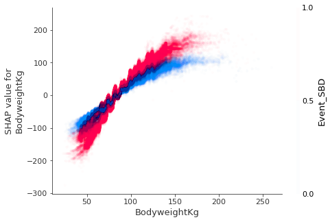

```
Passing parameters norm and vmin/vmax simultaneously is deprecated since 3.3 and will become an error two minor releases later. Please pass vmin/vmax directly to the norm when creating it.
```

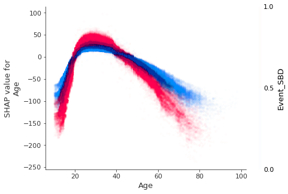

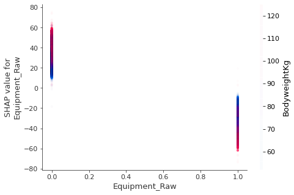

```python
shap.dependence_plot("rank(0)", shap_values, X_train, feature_names = X_col_names, alpha=0.01)
shap.dependence_plot("rank(1)", shap_values, X_train, feature_names = X_col_names, alpha=0.01)
shap.dependence_plot("rank(2)", shap_values, X_train, feature_names = X_col_names, alpha=0.01)
shap.dependence_plot("rank(3)", shap_values, X_train, feature_names = X_col_names, alpha=0.01)
shap.dependence_plot("rank(4)", shap_values, X_train, feature_names = X_col_names, alpha=0.01)
```

Event_SBD is such a strong factor, it's interacting with quite a lot here. Interesting how lifters between the ages of 20-40 (in their prime), doing full powerlifting meets tended to lift more (above the impact of the full powerlifting meet).

These clouds of SHAP values are a little harder to interpret, so I've averaged it out in the graphs below.

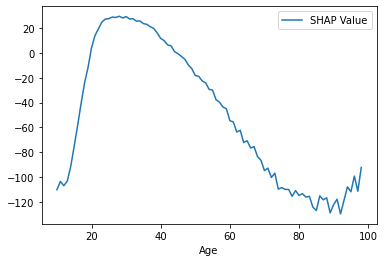

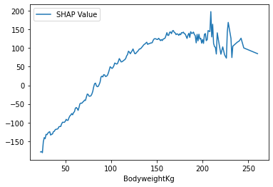

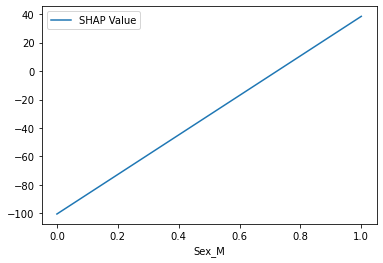

```python
def shap_plot_mean(var):
    shap_df = pd.DataFrame({"SHAP Value":shap_values[:,X_col_names.get_indexer([var])[0]], var:X_train.iloc[:,X_col_names.get_indexer([var])[0]]}).round().groupby(var).mean()
    shap_df.plot()

shap_plot_mean("Age")
shap_plot_mean("BodyweightKg")
shap_plot_mean("Sex_M")
```

Based off the above, you'll only taper off in performance after the age of 35 (noting the self-selection bias of the data), not suprisingly bodyweight increases weight lifted (albeit with diminishing returns), and the typical male powerlifter lifts about 140kg more than the typical female powerlifter.